# Mason Yokum Spin Deviation Report

Cael Laird

2024-10-08

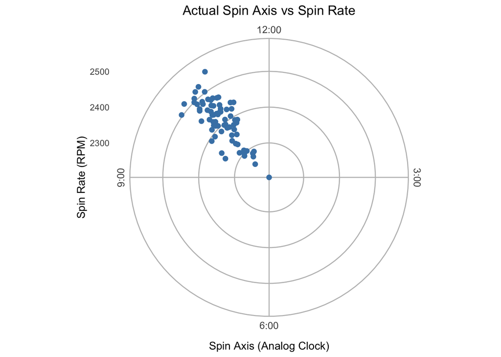

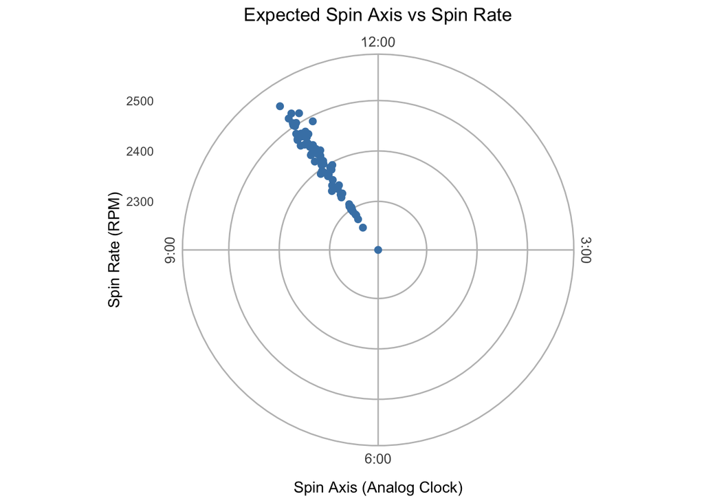

```
## [1] 8.691893
```

Yokum Performance by Spin Axis Deviation

| Group | Pitches | BAABIP | SLG Against | Whiff% | Called Strike % | Chase Rate | Out+Strike% |
| --- | --- | --- | --- | --- | --- | --- | --- |
| High Deviation | 9 | 0.000 | 0.000 | 25 | 37.50 | 0.25 | 75 |
| Low Deviation | 65 | 0.308 | 0.538 | 0 | 23.64 | 0.00 | 40 |

Yokum Sample Variance

| Variance |
| --- |
| 46.41701 |

- The graphs above show the deviation from Yokum’s expected axis when releasing the ball to what actual happens.
- When Yokum threw pitches with high deviation he had far better success across multiple variables then he did on pitches with low deviation.
- Yokum’s deviation fall in a standard deviation right under 7, so around 68% of his pitches are within 14 degrees of eachother, resulting in low deviation.
- In order for Yokum to have more success with the fastball, he will need to find ways to create higher deviation in expected vs. actual axis.
- Yokum has dealt with control issues in the past, so coaches have emphasized hitting his spots. However, to take his fastball to the next level, he will need to create consistent high deviation, while holding the ability to spot up.
- It is important to note that this data is from a small sample size from only the fall, so percentages will highly fluctuate.